# [ 시각화 - Matplotlib, Seaborn ]

- [T-Academy X KaKr] 성인 인구조사 소득 예측 대회
- dataset : https://www.kaggle.com/c/kakr-4th-competition/

### [ Matplotlib ]

- 그래프 출력 : plot(), subplot()
- 히스토그램 : hist()

### [ Seaborn ]

- 막대그래프 : barplot(), countplot()
- 상자그림 : boxplot()
- 회귀분석(회귀직선 & 산점도) : lmplot()
- 히트맵 : heatmap() - dataset.pivot()

```python
import pandas as pd

train = pd.read_csv("Income_train.csv")
test = pd.read_csv("Income_test.csv")
sub = pd.read_csv("Income_sample_submission.csv")
```

```python
train.shape, test.shape, sub.shape
```

```
((26049, 16), (6512, 15), (6512, 2))
```

```python
train
```

|  | id | age | workclass | fnlwgt | education | education_num | marital_status | occupation | relationship | race | sex | capital_gain | capital_loss | hours_per_week | native_country | income |
| --- | --- | --- | --- | --- | --- | --- | --- | --- | --- | --- | --- | --- | --- | --- | --- | --- |
| 0 | 0 | 40 | Private | 168538 | HS-grad | 9 | Married-civ-spouse | Sales | Husband | White | Male | 0 | 0 | 60 | United-States | >50K |
| 1 | 1 | 17 | Private | 101626 | 9th | 5 | Never-married | Machine-op-inspct | Own-child | White | Male | 0 | 0 | 20 | United-States | <=50K |
| 2 | 2 | 18 | Private | 353358 | Some-college | 10 | Never-married | Other-service | Own-child | White | Male | 0 | 0 | 16 | United-States | <=50K |
| 3 | 3 | 21 | Private | 151158 | Some-college | 10 | Never-married | Prof-specialty | Own-child | White | Female | 0 | 0 | 25 | United-States | <=50K |
| 4 | 4 | 24 | Private | 122234 | Some-college | 10 | Never-married | Adm-clerical | Not-in-family | Black | Female | 0 | 0 | 20 | ? | <=50K |
| ... | ... | ... | ... | ... | ... | ... | ... | ... | ... | ... | ... | ... | ... | ... | ... | ... |
| 26044 | 26044 | 57 | Private | 250201 | 11th | 7 | Married-civ-spouse | Other-service | Husband | White | Male | 0 | 0 | 52 | United-States | <=50K |
| 26045 | 26045 | 23 | Private | 238092 | Bachelors | 13 | Never-married | Prof-specialty | Own-child | White | Male | 0 | 0 | 40 | United-States | <=50K |
| 26046 | 26046 | 78 | ? | 165694 | Masters | 14 | Widowed | ? | Not-in-family | White | Female | 0 | 0 | 15 | United-States | <=50K |
| 26047 | 26047 | 26 | Self-emp-not-inc | 151626 | HS-grad | 9 | Never-married | Prof-specialty | Own-child | Black | Female | 0 | 0 | 40 | United-States | <=50K |
| 26048 | 26048 | 20 | ? | 99891 | Some-college | 10 | Never-married | ? | Own-child | White | Female | 0 | 0 | 30 | United-States | <=50K |

26049 rows × 16 columns

```python
test
```

|  | id | age | workclass | fnlwgt | education | education_num | marital_status | occupation | relationship | race | sex | capital_gain | capital_loss | hours_per_week | native_country |
| --- | --- | --- | --- | --- | --- | --- | --- | --- | --- | --- | --- | --- | --- | --- | --- |
| 0 | 0 | 28 | Private | 67661 | Some-college | 10 | Never-married | Adm-clerical | Other-relative | White | Female | 0 | 0 | 40 | United-States |
| 1 | 1 | 40 | Self-emp-inc | 37869 | HS-grad | 9 | Married-civ-spouse | Exec-managerial | Husband | White | Male | 0 | 0 | 50 | United-States |
| 2 | 2 | 20 | Private | 109952 | Some-college | 10 | Never-married | Handlers-cleaners | Own-child | White | Male | 0 | 0 | 25 | United-States |
| 3 | 3 | 40 | Private | 114537 | Assoc-voc | 11 | Married-civ-spouse | Exec-managerial | Husband | White | Male | 0 | 0 | 50 | United-States |
| 4 | 4 | 37 | Private | 51264 | Doctorate | 16 | Married-civ-spouse | Prof-specialty | Husband | White | Male | 0 | 0 | 99 | France |
| ... | ... | ... | ... | ... | ... | ... | ... | ... | ... | ... | ... | ... | ... | ... | ... |
| 6507 | 6507 | 35 | Private | 61343 | Bachelors | 13 | Married-civ-spouse | Sales | Husband | White | Male | 0 | 0 | 40 | United-States |
| 6508 | 6508 | 41 | Self-emp-inc | 32185 | Bachelors | 13 | Married-civ-spouse | Tech-support | Husband | White | Male | 0 | 0 | 40 | United-States |
| 6509 | 6509 | 39 | Private | 409189 | 5th-6th | 3 | Married-civ-spouse | Other-service | Husband | White | Male | 0 | 0 | 40 | Mexico |
| 6510 | 6510 | 35 | Private | 180342 | HS-grad | 9 | Married-civ-spouse | Craft-repair | Husband | White | Male | 0 | 0 | 40 | United-States |
| 6511 | 6511 | 28 | Private | 156819 | HS-grad | 9 | Divorced | Handlers-cleaners | Unmarried | White | Female | 0 | 0 | 36 | United-States |

6512 rows × 15 columns

```python
sub
```

|  | id | prediction |
| --- | --- | --- |
| 0 | 0 | 0 |
| 1 | 1 | 0 |
| 2 | 2 | 0 |
| 3 | 3 | 0 |
| 4 | 4 | 0 |
| ... | ... | ... |
| 6507 | 6507 | 0 |
| 6508 | 6508 | 0 |
| 6509 | 6509 | 0 |
| 6510 | 6510 | 0 |
| 6511 | 6511 | 0 |

6512 rows × 2 columns

```python
train.describe()
```

|  | id | age | fnlwgt | education_num | capital_gain | capital_loss | hours_per_week |
| --- | --- | --- | --- | --- | --- | --- | --- |
| count | 26049.000000 | 26049.000000 | 2.604900e+04 | 26049.000000 | 26049.00000 | 26049.000000 | 26049.000000 |
| mean | 13024.000000 | 38.569235 | 1.903045e+05 | 10.088372 | 1087.68970 | 87.732734 | 40.443126 |
| std | 7519.842917 | 13.671489 | 1.059663e+05 | 2.567610 | 7388.85469 | 403.230205 | 12.361850 |
| min | 0.000000 | 17.000000 | 1.376900e+04 | 1.000000 | 0.00000 | 0.000000 | 1.000000 |
| 25% | 6512.000000 | 28.000000 | 1.181080e+05 | 9.000000 | 0.00000 | 0.000000 | 40.000000 |
| 50% | 13024.000000 | 37.000000 | 1.788660e+05 | 10.000000 | 0.00000 | 0.000000 | 40.000000 |
| 75% | 19536.000000 | 48.000000 | 2.377350e+05 | 12.000000 | 0.00000 | 0.000000 | 45.000000 |
| max | 26048.000000 | 90.000000 | 1.484705e+06 | 16.000000 | 99999.00000 | 4356.000000 | 99.000000 |

```python
test.describe()
```

|  | id | age | fnlwgt | education_num | capital_gain | capital_loss | hours_per_week |
| --- | --- | --- | --- | --- | --- | --- | --- |
| count | 6512.000000 | 6512.000000 | 6.512000e+03 | 6512.000000 | 6512.000000 | 6512.000000 | 6512.000000 |
| mean | 3255.500000 | 38.631296 | 1.876738e+05 | 10.049908 | 1037.483876 | 85.588145 | 40.414773 |
| std | 1879.996809 | 13.516418 | 1.038493e+05 | 2.593033 | 7371.453668 | 401.904741 | 12.290491 |
| min | 0.000000 | 17.000000 | 1.228500e+04 | 1.000000 | 0.000000 | 0.000000 | 1.000000 |
| 25% | 1627.750000 | 28.000000 | 1.165042e+05 | 9.000000 | 0.000000 | 0.000000 | 40.000000 |
| 50% | 3255.500000 | 37.000000 | 1.768820e+05 | 10.000000 | 0.000000 | 0.000000 | 40.000000 |
| 75% | 4883.250000 | 48.000000 | 2.358508e+05 | 12.000000 | 0.000000 | 0.000000 | 45.000000 |
| max | 6511.000000 | 90.000000 | 1.125613e+06 | 16.000000 | 99999.000000 | 4356.000000 | 99.000000 |

```python
print(train.isnull().sum(), "\n")
print(test.isnull().sum())
```

```
id                0
age               0
workclass         0
fnlwgt            0
education         0
education_num     0
marital_status    0
occupation        0
relationship      0
race              0
sex               0
capital_gain      0
capital_loss      0
hours_per_week    0
native_country    0
income            0
dtype: int64

id                0
age               0
workclass         0
fnlwgt            0
education         0
education_num     0
marital_status    0
occupation        0
relationship      0
race              0
sex               0
capital_gain      0
capital_loss      0
hours_per_week    0
native_country    0
dtype: int64
```

```python
print(train.info(), "\n")
print(test.info())
```

```
<class 'pandas.core.frame.DataFrame'>
RangeIndex: 26049 entries, 0 to 26048
Data columns (total 16 columns):
 #   Column          Non-Null Count  Dtype
---  ------          --------------  -----
 0   id              26049 non-null  int64
 1   age             26049 non-null  int64
 2   workclass       26049 non-null  object
 3   fnlwgt          26049 non-null  int64
 4   education       26049 non-null  object
 5   education_num   26049 non-null  int64
 6   marital_status  26049 non-null  object
 7   occupation      26049 non-null  object
 8   relationship    26049 non-null  object
 9   race            26049 non-null  object
 10  sex             26049 non-null  object
 11  capital_gain    26049 non-null  int64
 12  capital_loss    26049 non-null  int64
 13  hours_per_week  26049 non-null  int64
 14  native_country  26049 non-null  object
 15  income          26049 non-null  object
dtypes: int64(7), object(9)
memory usage: 3.2+ MB
None

<class 'pandas.core.frame.DataFrame'>
RangeIndex: 6512 entries, 0 to 6511
Data columns (total 15 columns):
 #   Column          Non-Null Count  Dtype
---  ------          --------------  -----
 0   id              6512 non-null   int64
 1   age             6512 non-null   int64
 2   workclass       6512 non-null   object
 3   fnlwgt          6512 non-null   int64
 4   education       6512 non-null   object
 5   education_num   6512 non-null   int64
 6   marital_status  6512 non-null   object
 7   occupation      6512 non-null   object
 8   relationship    6512 non-null   object
 9   race            6512 non-null   object
 10  sex             6512 non-null   object
 11  capital_gain    6512 non-null   int64
 12  capital_loss    6512 non-null   int64
 13  hours_per_week  6512 non-null   int64
 14  native_country  6512 non-null   object
dtypes: int64(7), object(8)
memory usage: 763.2+ KB
None
```

```python
train.columns
```

```
Index(['id', 'age', 'workclass', 'fnlwgt', 'education', 'education_num',
       'marital_status', 'occupation', 'relationship', 'race', 'sex',
       'capital_gain', 'capital_loss', 'hours_per_week', 'native_country',
       'income'],
      dtype='object')
```

# [ Matplotlib ]

### 히스토그램 (hist) : 수치형 데이터

```python
import matplotlib.pyplot as plt
```

```python
import matplotlib

print(matplotlib.__version__)
```

```
3.2.2
```

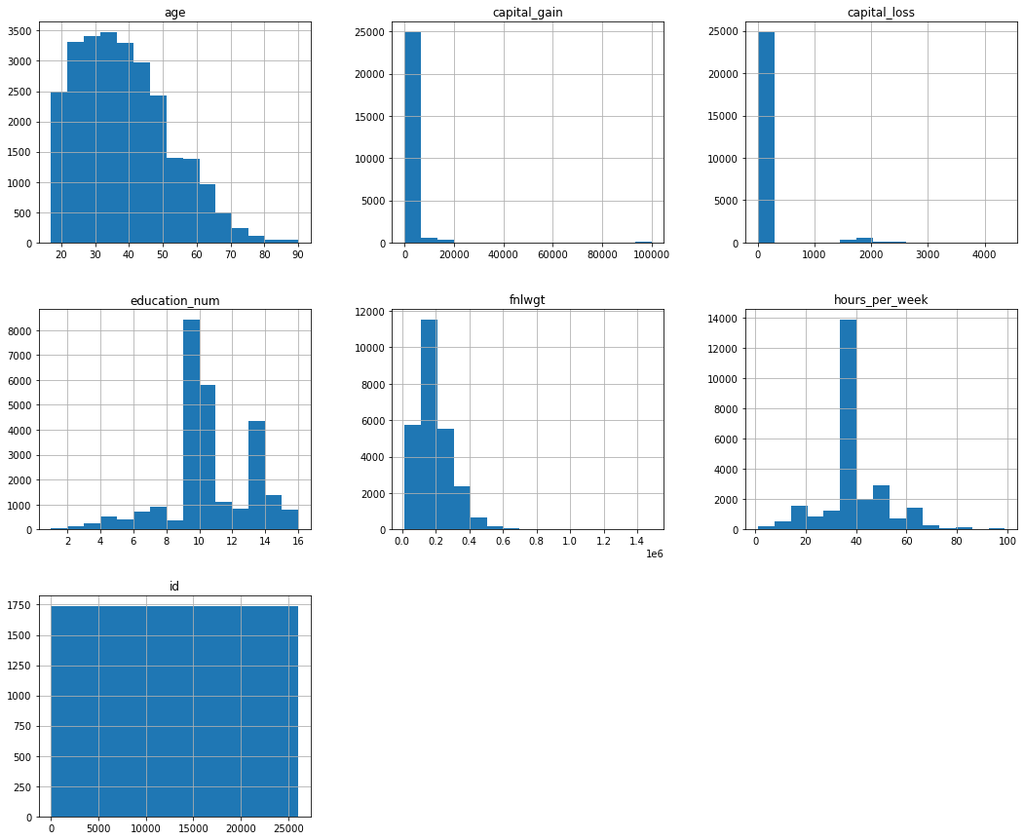

```python
train.hist(bins=15, figsize=(18, 15))   # bins : 막대 그래프 개수. default==10   # y 축 : 개수.
plt.show()
```

# [ Seaborn ]

### 막대그래프 1 (barplot)

```python
import seaborn as sns

print(sns.__version__)
```

```
0.10.1
```

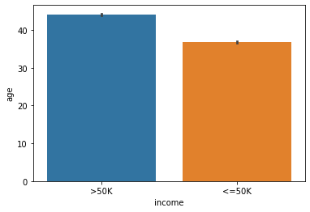

```python
# 연령별 연봉

sns.barplot(x="income", y="age", data=train)
```

< 그래프 해석 >

- 연봉이 5만 불 초과인 사람들의 평균 연령은 40대 초중반이다.
- 연봉이 5만 불 이하인 사람들의 평균 연령은 30대 후반이다.

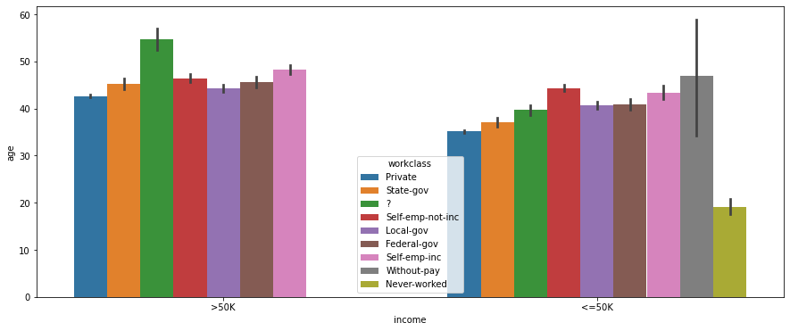

```python
# 연령대 및 고용 형태별 연봉

plt.figure(figsize=(15, 6))
sns.barplot(x="income", y="age", hue="workclass", data=train)
plt.show()
```

< 그래프 해석 >

- 연봉이 5만 불 초과인 경우
  - 고용 형태를 알 수 없는(?) 사람들의 평균 연령은 50대 중반으로 가장 나이가 많다.
  - 고용 형태가 비공개인(Private) 사람들의 평균 연령은 40대 초반으로 가장 나이가 적다.
- 연봉이 5만 불 미만인 경우
  - 돈을 받지 않고 근로를 하는(Without-pay) 사람들의 평균 연령은 40대 후반으로 가장 나이가 많다.
  - 한번도 근로를 하지 않은 사람들의 평균 연령은 10대 후반으로 나이가 가장 적다.

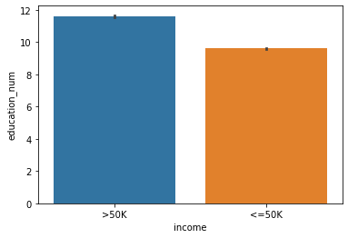

```python
# 교육 수준 수치별 연봉

sns.barplot(x="income", y="education_num", data=train)
```

< 그래프 해석 >

- 연봉이 5만 불 초과인 사람들의 평균 교육 수준 수치는 약 12점이다.
- 연봉이 5만 불 이하인 사람들의 평균 교육 수준 수치는 약 10점이다.

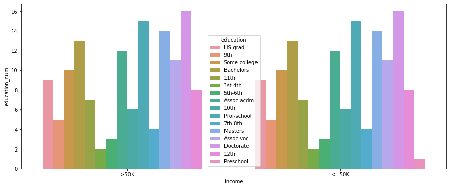

```python
# 교육 수준 수치 및 교육 수준별 연봉

plt.figure(figsize=(15, 6))
sns.barplot(x="income", y="education_num", hue="education", data=train)
plt.show()
```

< 그래프 해석 >

- 연봉이 5만 불 초과인 사람들과 5만 불 이하인 사람들의 교육 수준별 교육 수준 수치는 꽤 비슷하다.
- 공통점은 박사(Doctorate) 학위를 취득한 사람들의 평균 교육 수준 수치가 가장 높다.
- 차이점은 연봉이 5만 불 초과인 사람들 중에는 최종학력이 유치원(Preschool) 졸업인 경우가 없지만
- 반대로 연봉이 5만 불 이하인 사람들 중에는 최종학력이 유치원(Preschool) 졸업인 경우가 있다.

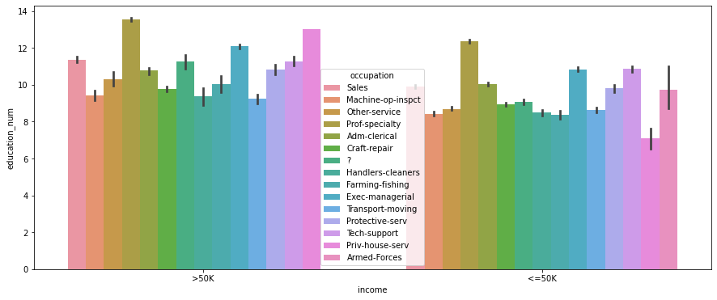

```python
# 교육 수준 수치 및 업종별 연봉

plt.figure(figsize=(15, 6))
sns.barplot(x="income", y="education_num", hue="occupation", data=train)
plt.show()
```

< 그래프 해석 >

- 연봉이 5만 불 초과인 경우
  - 평균적으로 Prof-specialty, Priv-house-serv, Exec-managerial 순으로 교육 수준 수치가 높다.
  - 평균적으로 Transport-moving, Handlers-cleaners, Machine-op-inspct 순으로 교육 수준 수치가 낮다.
- 연봉이 5만 불 미만인 경우
  - 평균적으로 Prof-specialty, Tech-support, Exec-managerial 순으로 교육 수준 수치가 높다.
  - 평균적으로 Priv-house-serv, Farming-fishing, Machine-op-inspct 순으로 교육 수준 수치가 낮다.

### 막대그래프 2 (countplot)

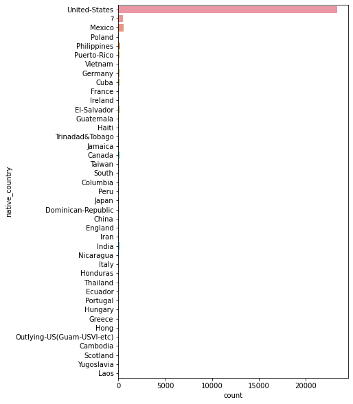

```python
# 국적

plt.figure(figsize=(6, 10))
sns.countplot(y="native_country", data=train)
plt.show()
```

< 그래프 해석 >

- 표본집단의 국적은 압도적으로 미국이 많다. 즉 응답자의 대다수가 미국인이다.

### 박스플롯 (boxplot)

boxplot 보충

- 최댓값(maximum) : 제 3사분위에서 1.5*IQR을 더한 위치. # IQR : 사분위간 범위. 즉 Q3-Q1.
- 제 3사분위(Q3)(upper quartile) : 75% 위치.
- 제 2사분위(Q2)(median) : 50% 위치. 중앙값.
- 제 1사분위(Q1)(lower quartile) : 25% 위치.
- 최솟값(minimun) : 제 1사분위에서 1.5*IQR1을 뺀 위치.
- 이상치(outlier)(다이아몬드 모양) : 최솟값과 최댓값을 넘어가는 위치에 있는 값.

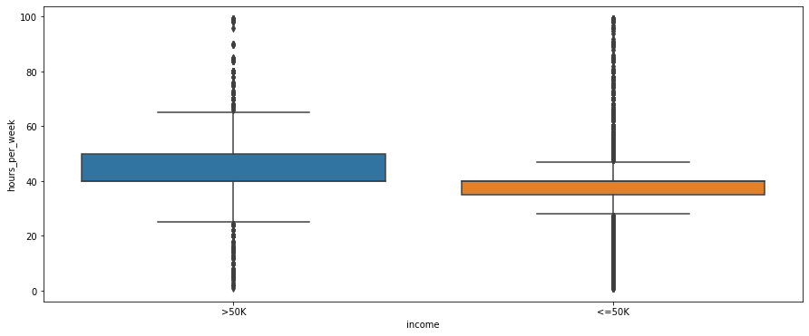

```python
# 주당 근무 시간별 연봉

plt.figure(figsize=(15, 6))
sns.boxplot(x="income", y="hours_per_week", data=train)
plt.show()
```

< 그래프 해석 >

- 평균적으로 연봉이 5만 불 초과인 사람들이 5만 불 이하인 사람들보다 주당 근무 시간이 더 길다.
- 연봉이 5만 불 초과인 사람들의 1사분위(25%)가 5만 불 이하인 사람들의 3사분위(75%)와 비슷하다. (약 40시간)

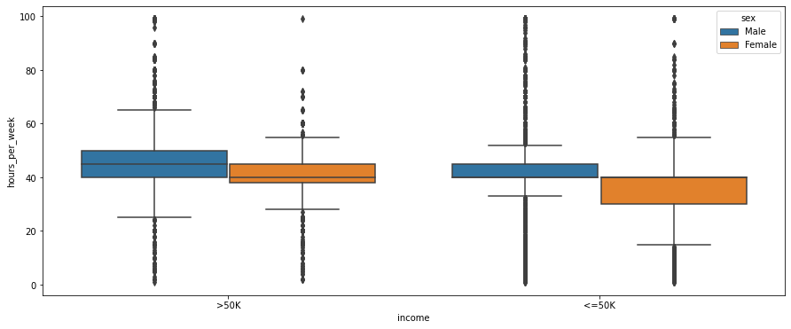

```python
# 성별 및 주당 근무 시간별 연봉

plt.figure(figsize=(15, 6))
sns.boxplot(x="income", y="hours_per_week", hue="sex", data=train)
plt.show()
```

< 그래프 해석 >

- 연봉이 5만 불 초과인 경우와 5만 불 이하인 경우 모두 평균적으로 남자가 여자보다 주당 근무 시간이 더 길다.
- 연봉이 5만 불 초과인 경우 남자의 2사분위(50%)가 여자의 3사분위(75%)와 비슷하다.
- 연봉이 5만 불 이하인 경우 남자의 1사분위(25%)가 여자의 3사분위(75%)와 비슷하다.

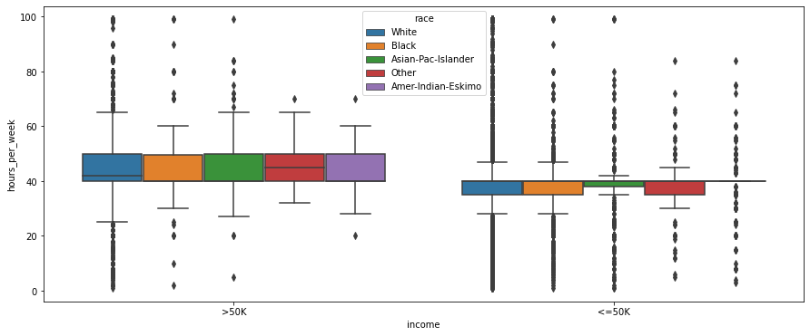

```python
# 인종 및 주당 근무 시간별 연봉

plt.figure(figsize=(15, 6))
sns.boxplot(x="income", y="hours_per_week", hue="race", data=train)
plt.show()
```

< 그래프 해석 >

- 연봉이 5만 불 초과인 경우
  - 모든 인종의 주당 근무 시간 1사분위(25%)와 3사분위(75%)가 비슷하다.
  - 하지만 White, Black, Asian-Pac_Islander의 경우 주당 근무 시간이 0~ 100시간까지 고르게 분포되어있는 반면
  - Others, Amer-Indian_Eskimo는 주당 근무 시간이 20~70 시간 사이에 분포해 있다.
- 연봉이 5만 불 이하인 경우
  - Amer-Indian_Eskimo를 제외하고 모든 인종의 주당 근무 시간 3사분위(75%)가 비슷하다.
  - 하지만 White, Black, Asian-Pac_Islander의 경우 주당 근무 시간이 0~ 100시간까지 고르게 분포되어있는 반면
  - Others, Amer-Indian_Eskimo는 주당 근무 시간이 5~85 시간 사이에 분포해 있다.

### 회귀분석(회귀직선 & 산점도) (lmplot)

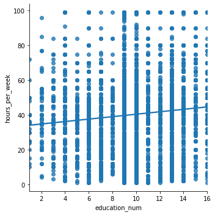

```python
# 교육 수준 수치별 주당 근무 시간

sns.lmplot(x="education_num", y="hours_per_week", data=train)
```

< 그래프 해석 >

- 교육 수준 수치가 높을수록 주당 근무 시간도 길다.
- 기울기로 미루어 봤을 때 교육 수준 수치가 최저일 때와(1) 최고일 때(16) 주당 근무 시간의 차이는 최대 10시간 정도이다.